# Provisioning Rate Repeatability

Freddie Mckendrick

29/01/2021

# Load Packages needed in repeatability analysis ————

```r
library(tidyverse)
library(Matrix)
library(coda)
library(ape)
library(MCMCglmm)
library(beepr)
library(rptR)
library(lme4)
library(insight)
library(parallel)
library(readxl)
library(lubridate)
library(magrittr)
```

# Load Provisioning data ———————–

- Load dataset
- Set columns to correct variable types

```r
Prov.rate <- read_csv("Data/FM_ProvisioningRate_20210114.csv")

Prov.rate$BirdID <- as.factor(Prov.rate$BirdID)
Prov.rate$Status <- as.factor(Prov.rate$Status)
Prov.rate$Sex <- as.factor(Prov.rate$SexEstimate) # 1 = male
Prov.rate$BGID <- as.factor(Prov.rate$BreedGroupID)
Prov.rate$NWID <- as.factor(Prov.rate$NestWatchID)
Prov.rate$NestID <- as.factor(Prov.rate$NestID)
Prov.rate$WatchDate <- dmy(Prov.rate$WatchDate)
Prov.rate$Month<- as.factor(Prov.rate$Month)
Prov.rate$Year<- as.factor(Prov.rate$Year)
Prov.rate$HelperNo <- as.integer(Prov.rate$HelperNumber)
Prov.rate$GroupSize <- as.integer(Prov.rate$GroupSize)
Prov.rate$TerritoryID <- as.factor(Prov.rate$TerritoryID)
Prov.rate$FPID <- as.factor(Prov.rate$FieldPeriodID)
```

Mean Centre age and divide by 2 standard deviations as in HE 2017 paper

```r
Prov.rate$Age_centred <- Prov.rate$Age-mean(Prov.rate$Age)
Age_sd <- sd(Prov.rate$Age)
Age_Two_sd <- 2*Age_sd
Prov.rate$Age_centred <- Prov.rate$Age_centred / Age_Two_sd
```

Standardise Provisioning rate data to feeds per hour to account for variation in the duration in nest watches

```r
Prov.rate$ProvFeeds <- as.integer(Prov.rate$ProvisioningVisit)
Prov.rate$ProvFeedsPerHour <- Prov.rate$ProvFeeds/(Prov.rate$ObsDuration/60)
#round provisioning feeds to the nearest integer
Prov.rate$ProvFeedsPerHour <- round(Prov.rate$ProvFeedsPerHour)
Prov.rate$ProvFeedsPerHour <- as.integer(Prov.rate$ProvFeedsPerHour)
```

Set helper number as Y/N No helpers = 0, helpers = 1

```r
Prov.rate %<>%
  mutate(HelperYN =
           case_when(HelperNo == 0 ~ "0",
                     HelperNo >= 1 ~ "1")
         )
```

# Identify NA records ———————–

Identify if there are any NAs in the dataset and if they need to be removed 35 rows have NAs in *One record (NWID = 659) has observer missing, gone into the archives and figured out it is most likely JT* One record (NWID = 728) has no start time *Four Records (NWID 2480, 2481 BrM + BrF) have no Chick number, brood size of number of fledglings* Remaining Twenty-nine records do not have number of fledglings

Need to remove records with no brood size (NWID = 2480, 2481) and no Observer

```r
NA_Values <- Prov.rate %>%  filter_all(any_vars(is.na(.)))
Prov.rate %>%
    select_if(function(x) any(is.na(x))) %>%
    summarise_each(funs(sum(is.na(.)))) -> extra_NA
extra_NA # breakdown of where there are NAs
```

```
## # A tibble: 1 x 5
##   StartTime ClutchSize BroodSize NoFledglings Observer
##       <int>      <int>     <int>        <int>    <int>
## 1         1          4         4           33        1
```

```r
#Remove 5 records
#Records that have no Brood size are NWID 2480,2481 from Nest 4778
#Record that has no observer NWID =659
Prov.rate %<>%
  filter( NestID != 4778) %>%
  filter(NWID != 659)
```

# Add NSA individuals into breed groups ———————

Only adding individuals assigned to single breed groups First Load data sets NSA_OneGroup = List of NSA individuals assinged to one breed group NSA_BGID = list of breed groups for all NSA individuals

```r
NSA_OneGroup <- read_csv("Data/FM_NSA_OneBG.csv")
NSA_BGID <- read_csv("Data/FM_NSA.csv")
```

Rename and set variables as correct format

```r
NSA_OneGroup$FieldPeriodID <- as.factor(NSA_OneGroup$FieldPeriodID)
NSA_OneGroup %<>%
  dplyr::rename(FPID = FieldPeriodID)
NSA_OneGroup$BirdID <- as.factor(NSA_OneGroup$BirdID)

NSA_BGID$FieldPeriodID <- as.factor(NSA_BGID$FieldPeriodID)
NSA_BGID %<>%
  dplyr::rename(FPID = FieldPeriodID)
NSA_BGID$BirdID <- as.factor(NSA_BGID$BirdID)
NSA_BGID %<>%
  dplyr::select(-(NSA_Birds))
```

Join tables together so that you have BirdID, Field Period ID, Breed Group ID and Territory ID all in one tibble

```r
NSA_OneGroup %<>% left_join(NSA_BGID)
NSA_OneGroup %<>%
  dplyr::rename(BGID = BreedGroupID)
NSA_OneGroup$BGID <- as.factor(NSA_OneGroup$BGID)
```

Count the number of NSA individuals within a breed group per field period, set it as a new tibble and change variable type * There are eight groups with 2 NSA in a Field Period * Two Groups with three NSA in a Field Period

```r
NumberOfBirds <- NSA_OneGroup %>%
  dplyr::count(FPID, BGID, TerritoryNumber)
NumberOfBirds$BGID <- as.factor(NumberOfBirds$BGID)
NumberOfBirds$FPID <- as.factor(NumberOfBirds$FPID)
```

Join this new tibble to Original Provisioning data. Change NA rows in NSA.individuals column to 0 * these represent Breed Groups with no NSA individuals Add the number of NSA individuals on to Group Size

```r
Prov.rate %<>% left_join(NumberOfBirds) #join data sets
Prov.rate %<>%
  dplyr::rename(NSA.Individuals = n) #rename count of NSA individual column
Prov.rate %<>%
  dplyr::mutate_at(dplyr::vars(NSA.Individuals), ~tidyr::replace_na(.,0)) #Replace NA rows with 0
Prov.rate %<>%
  dplyr::mutate(GroupSize = GroupSize + NSA.Individuals) #add NSA individuals to GroupSize
```

#Load Territory Quality data ———————-

Using Ellie and Sara’s code Need to replace missing territory qualities with mean from previous and following field periods Territory qualities are split into different field seasons to calculate average TQ

```r
#load data
TerritoryQuality_calc <- read_excel("Data/sys_TerritoryQuality.xlsx")
FPS_SummerIndex <- read_excel("Data/AllFPS_SummerIndex.xlsx")

#Set field periods as either summer or winter
FPS_SummerIndex$Season <- NA
FPS_SummerIndex$Season[FPS_SummerIndex$SummerIndex>=0.5] <- "Summer"
FPS_SummerIndex$Season[FPS_SummerIndex$SummerIndex<0.5] <- "Winter"
FPS_SummerIndex$midpoint <- as.Date((FPS_SummerIndex$PeriodStart) +
                                      ((difftime(FPS_SummerIndex$PeriodEnd, FPS_SummerIndex$PeriodStart , units = c("days")))/2))

FPS_SummerIndex <- subset(FPS_SummerIndex, select = c("TerritoryID", "FieldPeriodID", "Season", "midpoint"))

#Reduce territory quality data down to territory ID Field Period ID and the corrected Territory quality
#Then Link to field period data to link TQ to summer or winter field periods
TerritoryQuality_calc <- unique(subset(TerritoryQuality_calc, select = c("TerritoryID", "FieldPeriodID", "TQcorrected"), Island=="CN"))
TerritoryQuality_calc <- unique(merge(TerritoryQuality_calc, FPS_SummerIndex, by.x=c("TerritoryID", "FieldPeriodID"),
                                      by.y=c("TerritoryID", "FieldPeriodID"),
                                      all.x = TRUE,
                                      all.y = TRUE))
TerritoryQuality_calc %<>%
  arrange(TerritoryID, midpoint) %>%
  group_by(TerritoryID)

colnames(TerritoryQuality_calc)[colnames(TerritoryQuality_calc) == 'TQcorrected'] <- 'TQ'
TerritoryQuality_calc$prevTQ <- TerritoryQuality_calc$TQ
TerritoryQuality_calc$nextTQ <- TerritoryQuality_calc$TQ

#Subset data into summer and winter field periods so that you can calculate Territory quality for missing data points
TQ_winter <- subset(TerritoryQuality_calc, Season=="Winter")
TQ_summer <- subset(TerritoryQuality_calc, Season=="Summer")

#calculate mean TQ for missing rows
#winter
#Print the value of the most recent field period before current NA
TQ_winter %<>%
  group_by(TerritoryID) %>%
  tidyr::fill(prevTQ, .direction='updown')
#Print the value of the most recent field period after current NA
TQ_winter %<>%
  group_by(TerritoryID) %>%
  tidyr::fill(nextTQ, .direction='downup')
#Calculate mean of prev and next TQs
TQ_winter$TQ <- (TQ_winter$prevTQ + TQ_winter$nextTQ)/2

#summer
#Print the value of the most recent field period before current NA
TQ_summer %<>%
  group_by(TerritoryID) %>%
  tidyr::fill(prevTQ, .direction='updown')
#Print the value of the most recent field period after current NA
TQ_summer %<>%
  group_by(TerritoryID) %>%
  tidyr::fill(nextTQ, .direction='downup')
#Calculate mean of prev and next TQs
TQ_summer$TQ <- (TQ_summer$prevTQ + TQ_summer$nextTQ)/2

#Bind summer and winter seasons back together
TQ <- rbind(TQ_summer, TQ_winter)

#Refine dataset and change variables so that it matches Provisioning data
TQ <- subset(TQ, select = c("TerritoryID", "FieldPeriodID", "TQ"))
TQ %<>%
  dplyr::rename(FPID = FieldPeriodID)
TQ$FPID <- as.factor(TQ$FPID)
TQ$TerritoryID <- as.factor(TQ$TerritoryID)
#Join TQ to provisioning data
Prov.rate <- Prov.rate %>%
  left_join(TQ)
#mean centre Territory Quality
Prov.rate$TQ_centred <- Prov.rate$TQ-mean(Prov.rate$TQ)
#in HE 2017 Age was also divided by 2 standard deviations
TQ_sd <- sd(Prov.rate$TQ)
TQ_Two_sd <- 2*TQ_sd
Prov.rate$TQ_centred <- Prov.rate$TQ_centred / TQ_Two_sd
```

# Set Prov.rate as dataframe ———————–

MCMC didn’t really like me running it as a tibble

```r
Prov.rate <- as.data.frame(Prov.rate)
str(Prov.rate)
```

```
## 'data.frame':    1379 obs. of  39 variables:
##  $ BirdID           : Factor w/ 554 levels "25","51","64",..: 1 1 2 3 3 3 4 4 5 5 ...
##  $ Status           : Factor w/ 2 levels "BrF","BrM": 2 2 2 1 1 1 2 2 1 1 ...
##  $ BreedGroupID     : num  2106 2106 220 2133 2133 ...
##  $ FieldPeriodID    : num  19 19 25 19 19 19 19 21 19 19 ...
##  $ NestWatchID      : num  638 681 394 636 640 ...
##  $ WatchDate        : Date, format: "1995-07-21" "1995-07-28" ...
##  $ Month            : Factor w/ 6 levels "01","02","06",..: 4 4 6 4 4 4 4 4 5 5 ...
##  $ Year             : Factor w/ 22 levels "1995","1996",..: 1 1 4 1 1 1 1 2 1 1 ...
##  $ StartTime        : 'hms' num  14:27:00 09:00:00 11:15:00 08:33:00 ...
##   ..- attr(*, "units")= chr "secs"
##  $ Behaviour        : logi  FALSE FALSE FALSE FALSE FALSE FALSE ...
##  $ ProvisioningVisit: num  8 7 3 1 1 1 14 5 12 20 ...
##  $ ObsDuration      : num  90 85 60 90 90 35 90 30 60 60 ...
##  $ SexEstimate      : num  1 1 1 0 0 0 1 1 0 0 ...
##  $ Age              : num  4314 4321 4199 2896 2900 ...
##  $ TerritoryID      : Factor w/ 622 levels "1","2","3","4",..: 42 42 41 86 86 86 46 46 76 76 ...
##  $ ClutchSize       : num  1 1 1 1 1 1 1 1 1 1 ...
##  $ BroodSize        : num  1 1 1 1 1 1 1 1 1 1 ...
##  $ NoFledglings     : num  0 0 1 1 1 1 0 0 1 1 ...
##  $ WatchType        : chr  "FI" "FI" "FI" "FI" ...
##  $ NestID           : Factor w/ 515 levels "3","5","8","21",..: 215 215 29 171 171 171 168 206 169 169 ...
##  $ NestNumber       : num  1 1 1 1 1 1 1 1 1 1 ...
##  $ Island           : chr  "CN" "CN" "CN" "CN" ...
##  $ Accurate         : logi  TRUE TRUE TRUE TRUE TRUE TRUE ...
##  $ Observer         : chr  "JT" "JT" "SG" "JT" ...
##  $ HelperNumber     : num  0 0 0 1 1 1 0 1 1 1 ...
##  $ GroupSize        : num  3 3 3 3 3 3 2 3 3 3 ...
##  $ TerritoryNumber  : num  36 36 35 71 71 71 40 40 60 60 ...
##  $ Sex              : Factor w/ 2 levels "0","1": 2 2 2 1 1 1 2 2 1 1 ...
##  $ BGID             : Factor w/ 694 levels "13","15","23",..: 144 144 34 150 150 150 145 159 149 149 ...
##  $ NWID             : Factor w/ 719 levels "11","19","25",..: 194 209 125 192 195 197 418 184 210 424 ...
##  $ HelperNo         : int  0 0 0 1 1 1 0 1 1 1 ...
##  $ FPID             : Factor w/ 100 levels "19","21","22",..: 1 1 5 1 1 1 1 2 1 1 ...
##  $ Age_centred      : num  1.055 1.058 1.004 0.42 0.422 ...
##  $ ProvFeeds        : int  8 7 3 1 1 1 14 5 12 20 ...
##  $ ProvFeedsPerHour : int  5 5 3 1 1 2 9 10 12 20 ...
##  $ HelperYN         : chr  "0" "0" "0" "1" ...
##  $ NSA.Individuals  : num  0 0 0 0 0 0 0 0 0 0 ...
##  $ TQ               : num  24753 24753 45916 18953 18953 ...
```

[output cut: 16 more lines]

```
##   ..   Age = col_double(),
##   ..   TerritoryID = col_double(),
##   ..   ClutchSize = col_double(),
##   ..   BroodSize = col_double(),
##   ..   NoFledglings = col_double(),
##   ..   WatchType = col_character(),
##   ..   NestID = col_double(),
##   ..   NestNumber = col_double(),
##   ..   Island = col_character(),
##   ..   Accurate = col_logical(),
##   ..   Observer = col_character(),
##   ..   HelperNumber = col_double(),
##   ..   GroupSize = col_double(),
##   ..   TerritoryNumber = col_double()
##   .. )
```

# Create Visuals of Fixed Effects ————

First look at helper number Looks like increasing helper number might reduce provisioning rate but very small sample size for 3 helpers may effect this Will set Helper number as Y/N

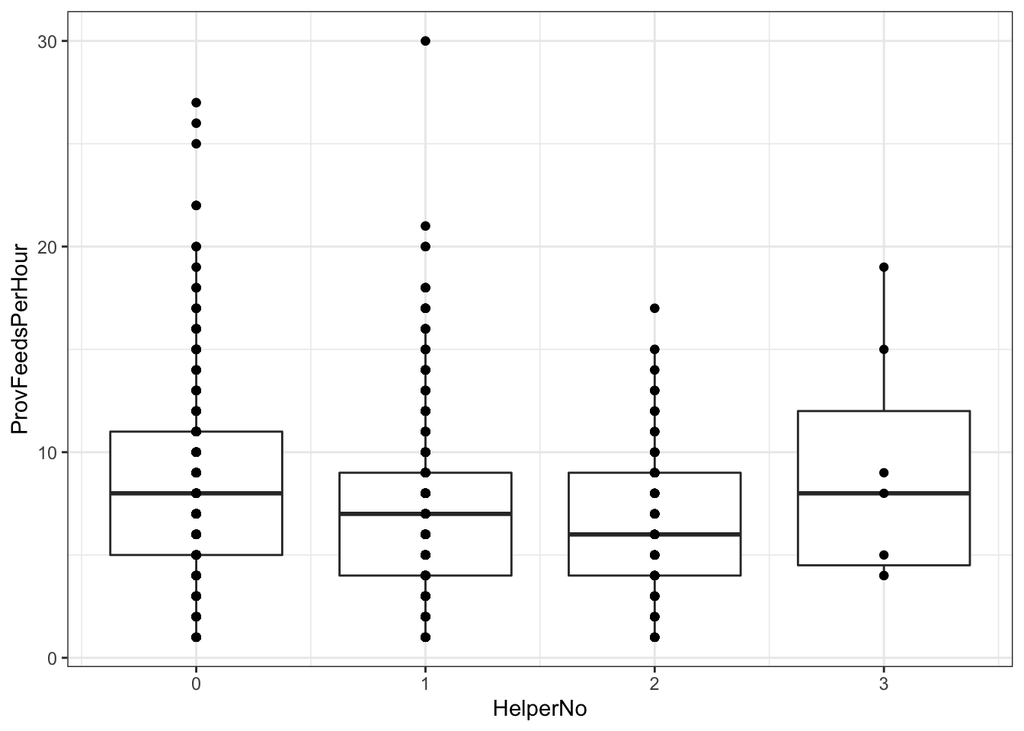

```r
ggplot(data = Prov.rate, aes(x = HelperNo, y = ProvFeedsPerHour, group = HelperNo)) + geom_boxplot() + geom_point(position=position_dodge(width=0.75)) + theme_bw()
```

# Setting Priors ———————-

prior1 is a inverse-wishart that should be the same as the default for MCMCglmm prior2 is a simple expanded parameter prior with large covariance matrix prior3 is a expanded parameter prior similar to that used in lotte provisioning paper

```r
#non-informative prior that should be same as default
#Predicts that the posterior distribution is not different from 0
#Four levels of G for four random effects
prior1<-list(R=list(V=1, nu=0.002),
             G = list(G1 = list(V = 1, nu = 0.002),
                      G2 = list(V = 1, nu = 0.002),
                      G3 = list(V = 1, nu = 0.002),
                      G4 = list(V = 1, nu = 0.002)))

#parameter expanded prior
#covariance matrix set as 1000
prior2 <- list(R = list(V = 1, nu = 0.002),
               G = list(G1 = list(V = 1, nu = 1, alpha.mu = 0, alpha.V = 1000),
                        G2 = list(V = 1, nu = 1, alpha.mu = 0, alpha.V = 1000),
                        G3 = list(V = 1, nu = 1, alpha.mu = 0, alpha.V = 1000),
                        G4 = list(V = 1, nu = 1, alpha.mu = 0, alpha.V = 1000)))

#could also use this one with nu closer to 0 as variances are quite small
#Similar to that set in Lottes paper

prior3 <- list(R = list(V = 1, nu = 0.002),
               G = list(G1 = list(V = 1, nu = 0.002, alpha.mu = 0, alpha.V = 1000),
                        G2 = list(V = 1, nu = 0.002, alpha.mu = 0, alpha.V = 1000),
                        G3 = list(V = 1, nu = 0.002, alpha.mu = 0, alpha.V = 1000),
                        G4 = list(V = 1, nu = 0.002, alpha.mu = 0, alpha.V = 1000)))
```

# Run MCMC model and check diagnostics ——————–

Model ran with Biologically relevant fixed effects Bird ID, Observer, Nest Id and Nest watch ID nested inside Nest ID ran as random effects

```r
Prov_rate_MCMC_model1 <-MCMCglmm(ProvFeedsPerHour ~ HelperNo + Sex + GroupSize + BroodSize + Age_centred + TQ_centred, random = ~BirdID + NestID + NestID:NWID + Observer, nitt=650000, burnin=50000, thin=300, prior = prior2, verbose = TRUE, family = "poisson",  data = Prov.rate)
```

[output not shown]

[output cut: 2549 more lines]

[output not shown]

Check Model Diagnostics First, see summary Shows that Helper Number, Brood size and Age all have significant effects on provisioning rate Confidence intervals for Sex, Group Size and Territory Quality all overlap 0

```r
summary(Prov_rate_MCMC_model1)
```

```
##
##  Iterations = 50001:649701
##  Thinning interval  = 300
##  Sample size  = 2000
##
##  DIC: 7206.988
##
##  G-structure:  ~BirdID
##
##        post.mean l-95% CI u-95% CI eff.samp
## BirdID   0.03194  0.01633  0.04811     2000
##
##                ~NestID
##
##        post.mean l-95% CI u-95% CI eff.samp
## NestID   0.03113 0.004761  0.05537     1318
##
##                ~NestID:NWID
##
##             post.mean  l-95% CI u-95% CI eff.samp
## NestID:NWID   0.02685 1.624e-06  0.05192     1327
##
##                ~Observer
##
##          post.mean l-95% CI u-95% CI eff.samp
## Observer   0.03761  0.01387  0.06605     1870
##
##  R-structure:  ~units
##
##       post.mean l-95% CI u-95% CI eff.samp
## units   0.04241   0.0193  0.06598     1705
##
##  Location effects: ProvFeedsPerHour ~ HelperNo + Sex + GroupSize + BroodSize + Age_centred + TQ_centred
##
##             post.mean l-95% CI u-95% CI eff.samp  pMCMC
## (Intercept)   1.73818  1.52138  1.93330     2000 <5e-04 ***
## HelperNo     -0.10796 -0.17893 -0.04037     2000  0.001 ***
## Sex1         -0.01502 -0.07865  0.03705     2000  0.615
## GroupSize     0.02145 -0.02850  0.08016     2000  0.470
## BroodSize     0.16399  0.06793  0.27792     1724  0.007 **
## Age_centred  -0.11997 -0.17646 -0.05354     2000 <5e-04 ***
## TQ_centred    0.03719 -0.04065  0.10981     2205  0.329
## ---
## Signif. codes:  0 '***' 0.001 '**' 0.01 '*' 0.05 '.' 0.1 ' ' 1
```

```r
round(sort(effectiveSize(Prov_rate_MCMC_model1$Sol)))
```

```
##   BroodSize   GroupSize Age_centred    HelperNo (Intercept)        Sex1
##        1724        2000        2000        2000        2000        2000
##  TQ_centred
##        2205
```

```r
round(sort(effectiveSize(Prov_rate_MCMC_model1$VCV)))
```

```
##      NestID NestID:NWID       units    Observer      BirdID
##        1318        1327        1705        1870        2000
```

Produce Summary plots to assess model convergence All look like they have converged

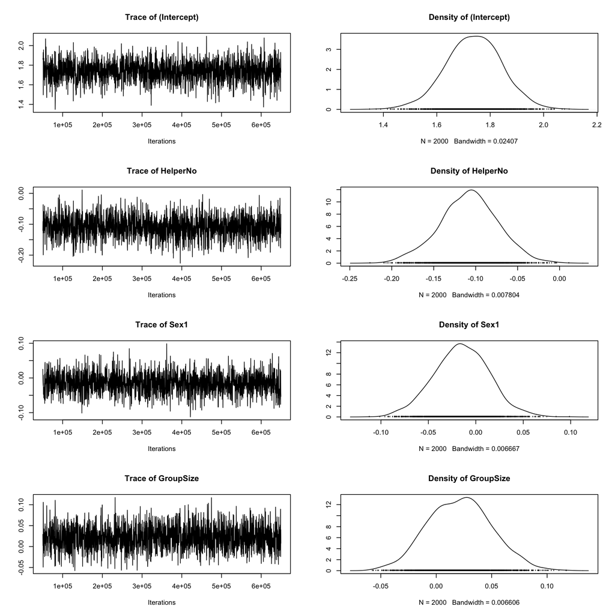

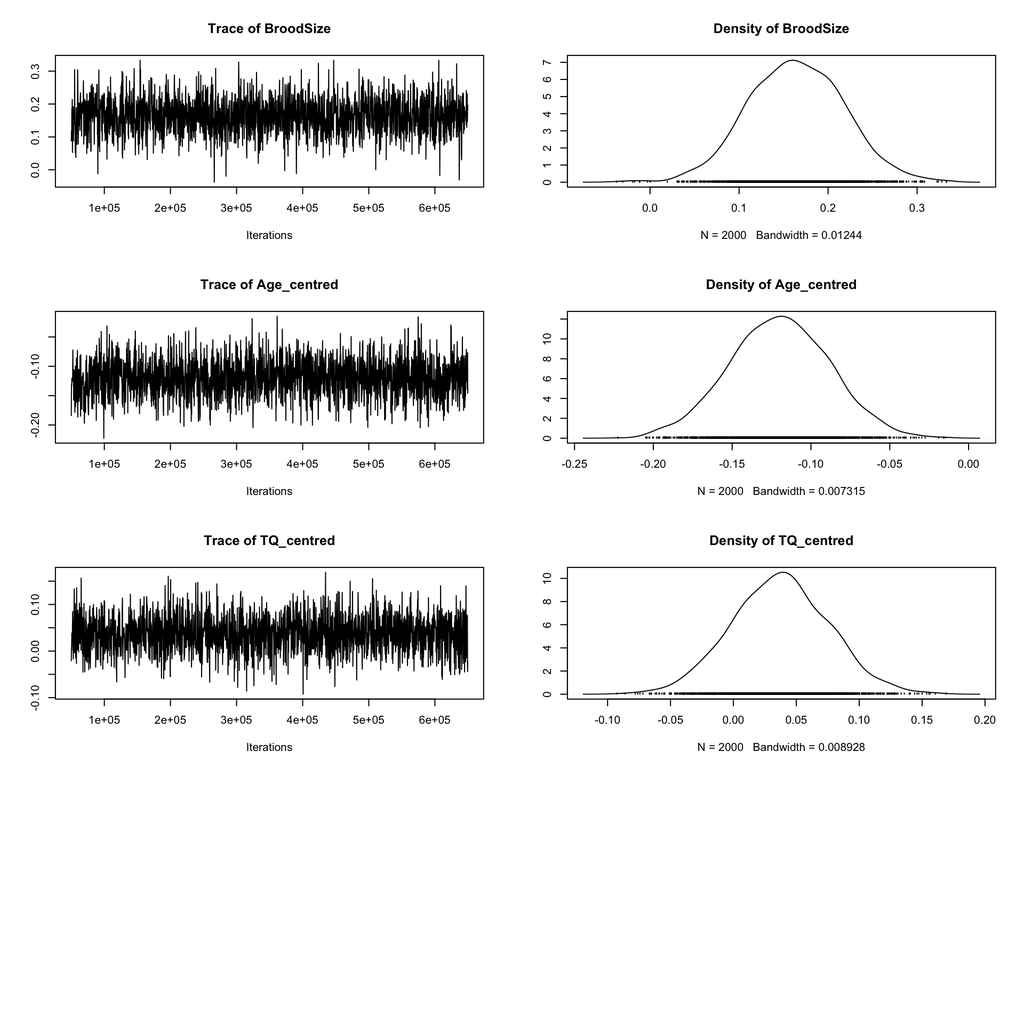

```r
plot(Prov_rate_MCMC_model1$Sol)
```

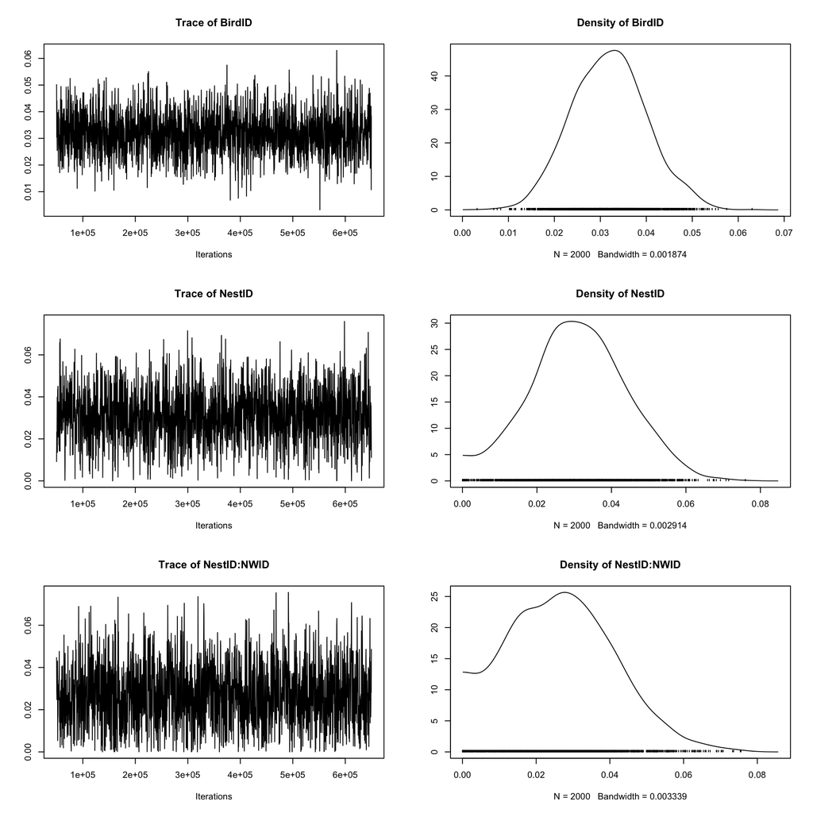

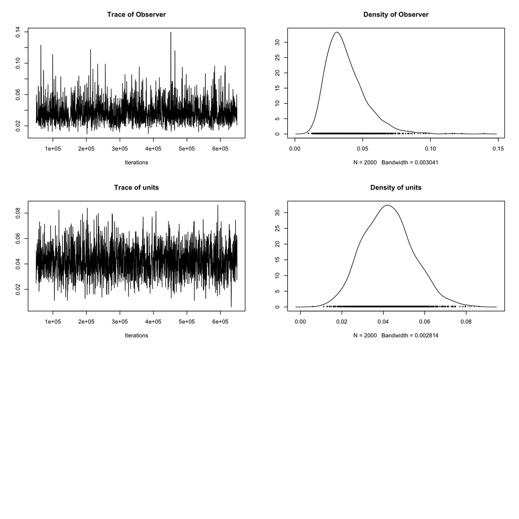

```r
plot(Prov_rate_MCMC_model1$VCV)
```

Check convergence diagnostics Heidel/Welch diagnostic * All must pass Geweke diagnostic * Checks similarity between first 10% and last 50% * All should be less than 2

```r
heidel.diag(Prov_rate_MCMC_model1$Sol)
```

```
##
##             Stationarity start     p-value
##             test         iteration
## (Intercept) passed       1         0.866
## HelperNo    passed       1         0.151
## Sex1        passed       1         0.262
## GroupSize   passed       1         0.149
## BroodSize   passed       1         0.836
## Age_centred passed       1         0.118
## TQ_centred  passed       1         0.717
##
##             Halfwidth Mean    Halfwidth
##             test
## (Intercept) passed     1.7382 0.00459
## HelperNo    passed    -0.1080 0.00152
## Sex1        passed    -0.0150 0.00127
## GroupSize   passed     0.0215 0.00125
## BroodSize   passed     0.1640 0.00253
## Age_centred passed    -0.1200 0.00138
## TQ_centred  passed     0.0372 0.00161
```